# Definitu

Aida Marsal

2025-01-12

En primer lloc es necessari activar les llibreries necessaries pel codi

# 1. Creació d’un objecte Phyloseq

```r
physeq3 <- qza_to_phyloseq(
  features = "qiime2/tax_class/table_rarefied.qza",
  tree = "qiime2/alignment/rooted-tree.qza",
  taxonomy = "qiime2/tax_class/table_tax_sklearn.qza",
  metadata = "mice_data/mice_metadata.tsv"
)

physeq3
```

```
## phyloseq-class experiment-level object
## otu_table()   OTU Table:         [ 16672 taxa and 19 samples ]
## sample_data() Sample Data:       [ 19 samples by 8 sample variables ]
## tax_table()   Taxonomy Table:    [ 16672 taxa by 7 taxonomic ranks ]
## phy_tree()    Phylogenetic Tree: [ 16672 tips and 16671 internal nodes ]
```

# 2. Mesura de la riquesa: alfa-diversistat

Mesurem l’alfa-diversitat en funció del genotip. Ho farem amb els índex Observed, Chao1, ACE, Shannon i Simpson. A més, inclourem el p-valor que s’obté amb cada índex.

## En funció del genotip

```r
# Establim les mesures d'alfa-diversitat
alpha_means = c("Observed", "Chao1", "ACE", "Shannon", "Simpson")

# Calculem les mètriques d'alfa-diversitat, i ho combinem amb les metadades.
alpha_div <- estimate_richness(physeq3, measures = alpha_means)
metadata <- as.data.frame(sample_data(physeq3))
rownames(alpha_div) <- sub("^X", "", rownames(alpha_div))
combined_data <- cbind(alpha_div, metadata)

# Apliquem el test wilcoxon a totes les mètriques d'alfa-diversitat
alpha_div_genotype <- lapply(alpha_means, function(measure) {
  group_WT <- combined_data[[measure]][combined_data$Genotype == "WT"]
  group_KO <- combined_data[[measure]][combined_data$Genotype == "KO"]
  wilcox.test(group_WT, group_KO, exact = FALSE)
})

# Mostrem l'estadístic i p-valor del test per cada mètrica
alpha_div_genotype_df <- data.frame(
  Measure = alpha_means,
  p_value = sapply(alpha_div_genotype, function(test) test$p.value),
  Statistic = sapply(alpha_div_genotype, function(test) test$statistic)
)
alpha_div_genotype_df
```

| Measure | p_value | Statistic |
| --- | --- | --- |
| Observed | 0.3310867 | 54 |
| Chao1 | 0.2907660 | 55 |
| ACE | 0.3310867 | 54 |
| Shannon | 0.5261685 | 50 |
| Simpson | 0.9662933 | 41 |

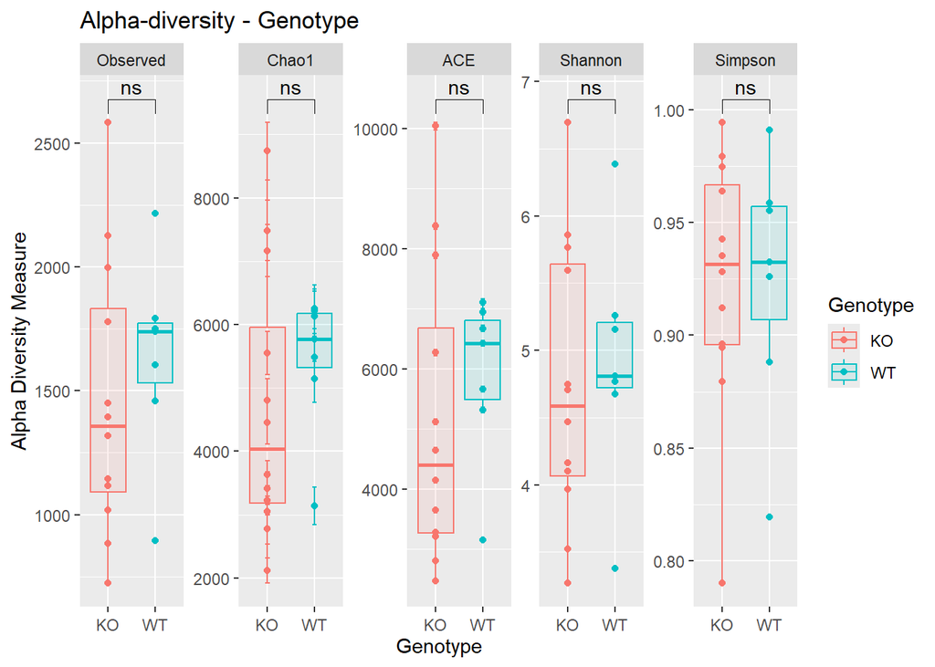

```r
# Representem l'alpha-diversitat segons genotip
plot_richness(physeq3, color = "Genotype", "Genotype", measures = alpha_means) +
  geom_boxplot(aes(fill = Genotype), alpha=0.1) +
  stat_compare_means(aes(label = ..p.signif..), method = "wilcox.test", comparisons = list(c("WT", "KO")), label = "p.format") +
  ggtitle("Alpha-diversity - Genotype") +
  theme(axis.text.x = element_text(angle = 0, hjust = 0.5))
```

```r
ggsave("alfa-div_genotype.jpeg", device = "jpeg", path = "R_analysis", height = 8, width = 7)
```

## En funció de l’aparició de tumor, per cada genotip

```r
# Primer haurem de dividir l'objecte phyloseq segons el genotip de cadascun
physeq.WT = subset_samples(physeq3, Genotype == "WT")
physeq.KO = subset_samples(physeq3, Genotype == "KO")

# Per aplicar els tests també es filtren les dades d'alpha_div
subset_WT <- combined_data[combined_data$Genotype == "WT", ]
subset_KO <- combined_data[combined_data$Genotype == "KO", ]

# Alpha-diversitat segons l'aparició o no de tumor - WT
# Aplicació test de Wilcoxon
alpha_div_tumorWT <- lapply(alpha_means, function(measure) {
  group_WT_HCC <- subset_WT[[measure]][subset_WT$HCC..YES.NO. == "YES"]
  group_WT_noHCC <- combined_data[[measure]][subset_WT$HCC..YES.NO. == "NO"]
  wilcox.test(group_WT_HCC, group_WT_noHCC, exact = FALSE)
})

# Mostrem l'estadístic i p-valor del test per cada mètrica
alpha_div_HCC_WT_df <- data.frame(
  Measure = alpha_means,
  p_value = sapply(alpha_div_tumorWT, function(test) test$p.value),
  Statistic = sapply(alpha_div_tumorWT, function(test) test$statistic)
)
alpha_div_HCC_WT_df
```

| Measure | p_value | Statistic |
| --- | --- | --- |
| Observed | 0.7336468 | 18.5 |
| Chao1 | 0.7336468 | 18.5 |
| ACE | 1.0000000 | 16.5 |
| Shannon | 0.8649006 | 17.5 |
| Simpson | 0.8649006 | 17.5 |

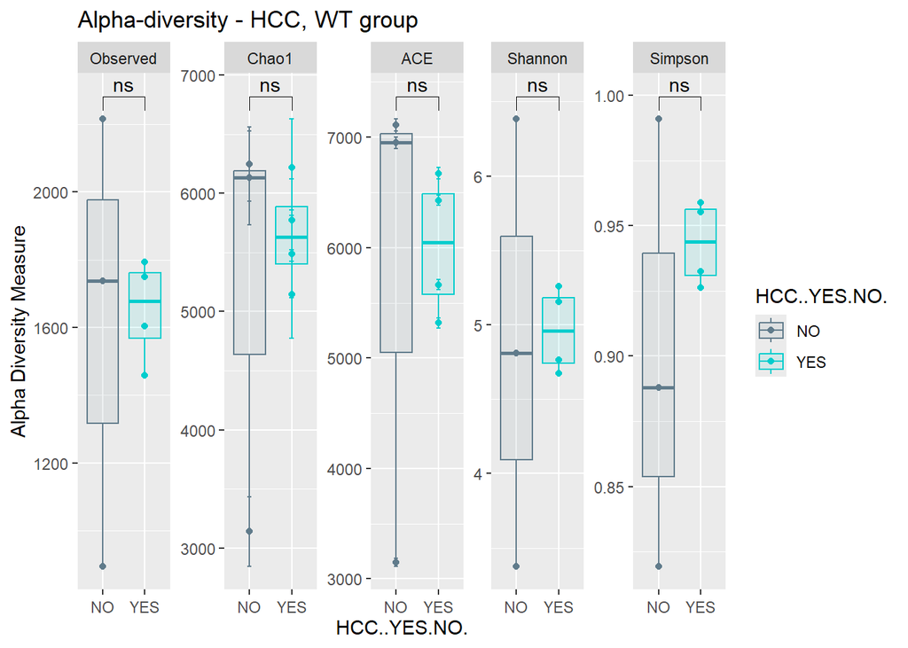

```r
# Representació gràfica
plot_richness(physeq.WT, color = "HCC..YES.NO.", "HCC..YES.NO.", measures = alpha_means) +
  geom_boxplot(aes(fill = HCC..YES.NO.), alpha=0.1) +
  stat_compare_means(aes(label = ..p.signif..), method = "wilcox.test", comparisons = list(c("YES", "NO")), label = "p.format") +
  scale_fill_manual(values = c("YES" = "#00CDCD", "NO" = "#607B8B")) +
  scale_color_manual(values = c("YES" = "#00CDCD", "NO" = "#607B8B"))+
  ggtitle("Alpha-diversity - HCC, WT group") +
  theme(axis.text.x = element_text(angle = 0, hjust = 0.5))
```

```r
ggsave("alfa-div_WT.jpeg", device = "jpeg", path = "R_analysis", height = 8, width = 7)
```

```r
# Alpha-diversitat segons l'aparició o no de tumor - KO
# Aplicació test de Wilcoxon
alpha_div_tumorKO <- lapply(alpha_means, function(measure) {
  group_KO_HCC <- subset_WT[[measure]][subset_KO$HCC..YES.NO. == "YES"]
  group_KO_noHCC <- combined_data[[measure]][subset_KO$HCC..YES.NO. == "NO"]
  wilcox.test(group_KO_HCC, group_KO_noHCC, exact = FALSE)
})

# Mostrem l'estadístic i p-valor del test per cada mètrica
alpha_div_HCC_KO_df <- data.frame(
  Measure = alpha_means,
  p_value = sapply(alpha_div_tumorKO, function(test) test$p.value),
  Statistic = sapply(alpha_div_tumorKO, function(test) test$statistic)
)
alpha_div_HCC_KO_df
```

| Measure | p_value | Statistic |
| --- | --- | --- |
| Observed | 0.9351699 | 18.5 |
| Chao1 | 0.8072104 | 15.5 |
| ACE | 0.6842205 | 14.5 |
| Shannon | 0.9351699 | 16.5 |
| Simpson | 0.9351699 | 16.5 |

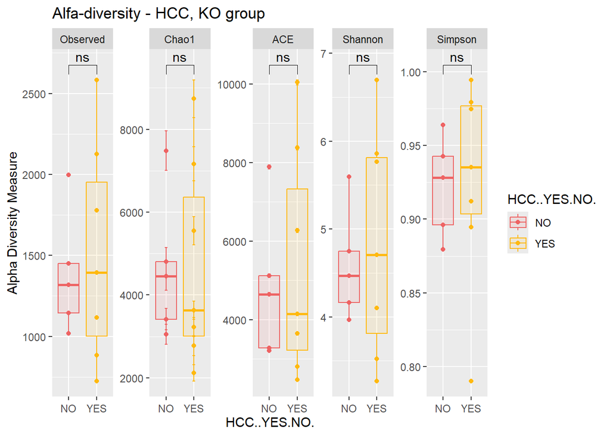

```r
# Representació gràfica
plot_richness(physeq.KO, color = "HCC..YES.NO.", "HCC..YES.NO.", measures = alpha_means) +
  geom_boxplot(aes(fill = HCC..YES.NO.), alpha=0.1) +
  stat_compare_means(aes(label = ..p.signif..), method = "wilcox.test", comparisons = list(c("YES", "NO")), label = "p.format") +
  scale_fill_manual(values = c("YES" = "#FFB90F", "NO" = "#EE6363")) +
  scale_color_manual(values = c("YES" = "#FFB90F", "NO" = "#EE6363"))+
  ggtitle("Alfa-diversity - HCC, KO group") +
  theme(axis.text.x = element_text(angle = 0, hjust = 0.5))
```

```r
ggsave("alfa-div_KO.jpeg", device = "jpeg", path = "R_analysis",  height = 8, width = 7)
```

```r
# Alpha-diversitat segons l'aparició o no de tumor - TOTAL
# Aplicació test de Wilcoxon
alpha_div_tumor <- lapply(alpha_means, function(measure) {
  group_YES <- combined_data[[measure]][combined_data$HCC..YES.NO. == "YES"]
  group_NO <- combined_data[[measure]][combined_data$HCC..YES.NO. == "NO"]
  wilcox.test(group_YES, group_NO, exact = FALSE)
})

# Mostrem l'estadístic i p-valor del test per cada mètrica
alpha_div_tumor_df <- data.frame(
  Measure = alpha_means,
  p_value = sapply(alpha_div_tumor, function(test) test$p.value),
  Statistic = sapply(alpha_div_tumor, function(test) test$statistic)
)
alpha_div_tumor_df
```

| Measure | p_value | Statistic |
| --- | --- | --- |
| Observed | 0.7102091 | 49 |
| Chao1 | 0.9014274 | 46 |
| ACE | 0.8364545 | 47 |
| Shannon | 0.6497226 | 50 |
| Simpson | 0.3859371 | 55 |

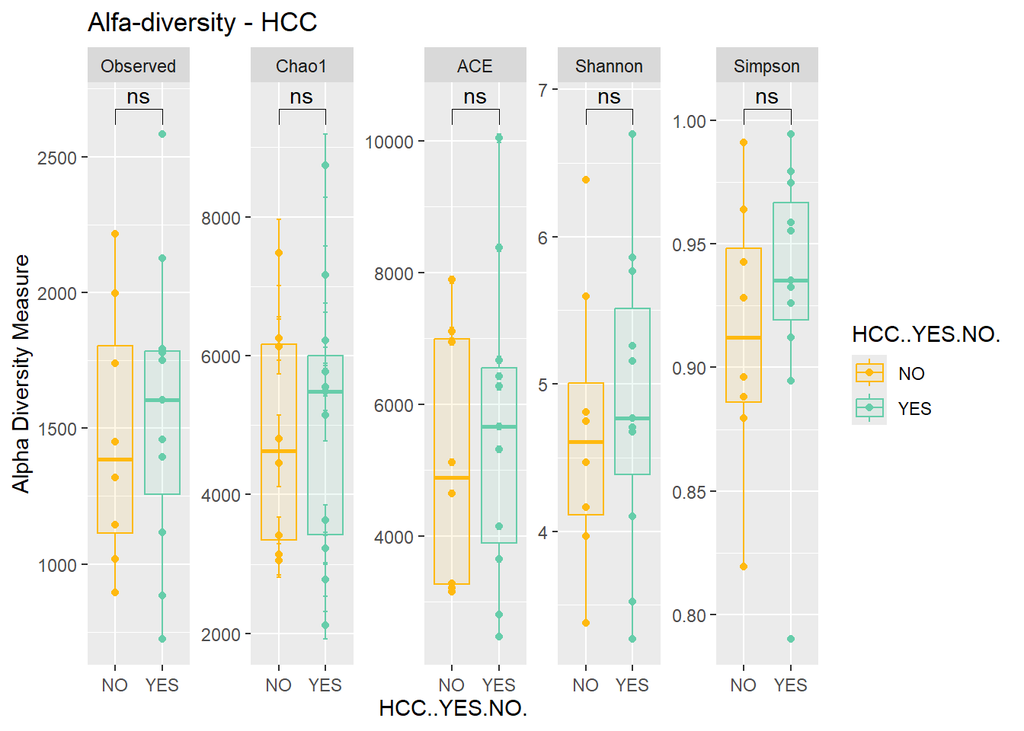

```r
# Representació gràfica
plot_richness(physeq3, color = "HCC..YES.NO.", "HCC..YES.NO.", measures = alpha_means) +
  geom_boxplot(aes(fill = HCC..YES.NO.), alpha=0.1) +
  stat_compare_means(aes(label = ..p.signif..), method = "wilcox.test", comparisons = list(c("YES", "NO")), label = "p.format") +
  scale_fill_manual(values = c("YES" = "#66CDAA", "NO" = "#FFB90F")) +
  scale_color_manual(values = c("YES" = "#66CDAA", "NO" = "#FFB90F"))+
  ggtitle("Alfa-diversity - HCC") +
  theme(axis.text.x = element_text(angle = 0, hjust = 0.5))
```

```r
ggsave("alfa-div_HCCt.jpeg", device = "jpeg", path = "R_analysis",  height = 8, width = 7)
```

# 3. Mesura de la riquesa: beta-diversitat

Per calcular la beta-diversitat, es fan servir dues distàncies diferents: unifrac i bray.

En primer lloc, utilitzem el test PERMANOVA basat en la matriu de distàncies unifrac i bray, en aquest cas en funció del genotip:

```r
# Calculem la matriu de distàncies unifrac
physeq.unifrac <- phyloseq::distance(physeq3, method= "unifrac")

# Test PERMANOVA - Genotype
permanova_unifrac_genotype <- adonis2(physeq.unifrac ~ Genotype, data = data.frame(sample_data(physeq3)), permutations= 999)
Pvalue_permanova_unifrac_genotype <- paste0("PERMANOVA p = ", signif(permanova_unifrac_genotype$`Pr(>F)`[1]))
```

```r
# Calculem la matriu de distàncies bray
physeq.bray <- phyloseq::distance(physeq3, method= "bray")

# Test PERMANOVA - Genotype
permanova_bray_genotype <- adonis2(physeq.bray ~ Genotype, data = data.frame(sample_data(physeq3)), permutations= 999)
Pvalue_permanova_bray_genotype <- paste0("PERMANOVA p = ", signif(permanova_bray_genotype$`Pr(>F)`[1]))
```

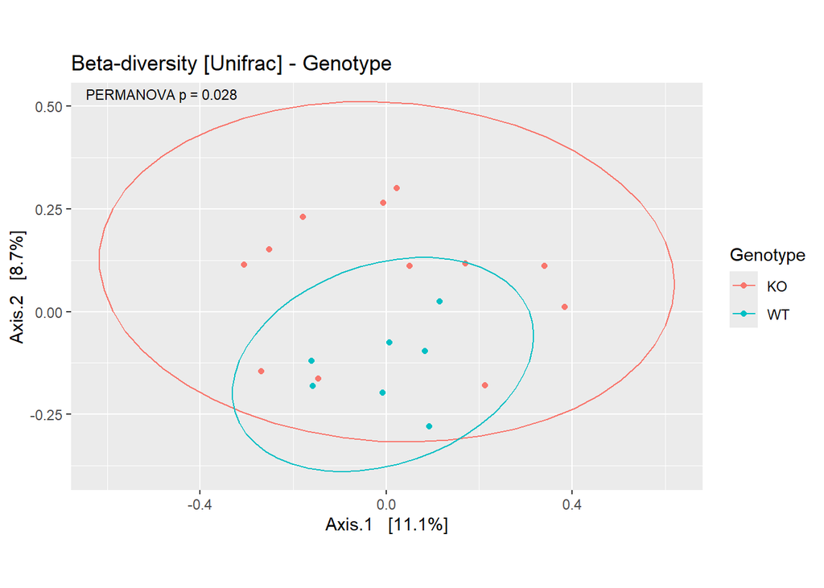

```r
# Calculem matriu de distància Unifrac
physeq3_unifrac <- ordinate(physeq3, method = "PCoA", distance = "unifrac")
evalues_unifrac <- physeq3_unifrac$values$Eigenvalues

# Gràfic d'ordenades per distància Unifrac
plot_ordination(physeq3, physeq3_unifrac, color = "Genotype") +
  labs(col = "Genotype") +
  coord_fixed(sqrt(evalues_unifrac[2]/ evalues_unifrac[1])) +
  stat_ellipse() +
  annotate("text", label = Pvalue_permanova_unifrac_genotype, x = -Inf, y = Inf,  hjust = -0.1, vjust = 1.5, size = 3) +
  ggtitle("Beta-diversity [Unifrac] - Genotype")
```

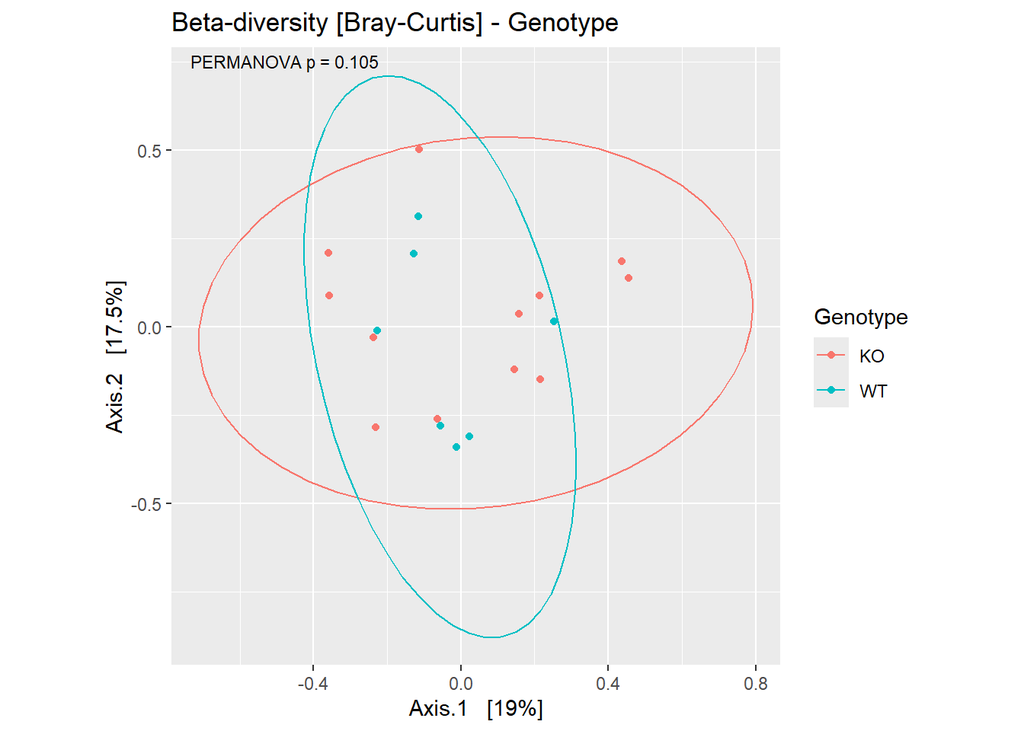

```r
ggsave("beta-div_Genotype_unifrac.jpeg", device = "jpeg", path = "R_analysis",  height = 8, width = 7)

# Càlcul matriu de distància Bray-Curtis
physeq3_bray <- ordinate(physeq3, method = "PCoA", distance = "bray")
evalues_bray <- physeq3_bray$values$Eigenvalues

# Gràfic d'ordenades per distància Bray-Curtis
plot_ordination(physeq3, physeq3_bray, color = "Genotype") +
  labs(col = "Genotype") +
  coord_fixed(sqrt(evalues_bray[2]/ evalues_bray[1])) +
  stat_ellipse() +
  annotate("text", label = Pvalue_permanova_bray_genotype, x = -Inf, y = Inf,  hjust = -0.1, vjust = 1.5, size = 3) +
  ggtitle("Beta-diversity [Bray-Curtis] - Genotype")
```

```r
ggsave("beta-div_Genotype_bray.jpeg", device = "jpeg", path = "R_analysis",  height = 8, width = 7)
```

## Segons aparició de tumors, grup WT

També es pot calcular segons l’aparició o no de tumors, per cada genotip:

```r
# Calculem la matriu de distàncies Unifrac
physeq.WT.unifrac <- phyloseq::distance(physeq.WT, method= "unifrac")

# Test PERMANOVA - WT/HCC
permanova_unifrac_WT.HCC <- adonis2(physeq.WT.unifrac ~ HCC..YES.NO., data = data.frame(sample_data(physeq.WT)), permutations= 999)
```

```
## Set of permutations < 'minperm'. Generating entire set.
```

```r
Pvalue_permanova_unifrac_WT.HCC <- paste0("PERMANOVA p = ", signif(permanova_unifrac_WT.HCC$`Pr(>F)`[1]))

# Calculem la matriu de distàncies Bray-Curtis
physeq.WT.bray <- phyloseq::distance(physeq.WT, method= "bray")

# Test PERMANOVA - WT/HCC
permanova_bray_WT.HCC <- adonis2(physeq.WT.bray ~ HCC..YES.NO., data = data.frame(sample_data(physeq.WT)), permutations= 999)
```

```
## Set of permutations < 'minperm'. Generating entire set.
```

```r
Pvalue_permanova_bray_WT.HCC <- paste0("PERMANOVA p = ", signif(permanova_bray_WT.HCC$`Pr(>F)`[1]))
```

```
## Too few points to calculate an ellipse
```

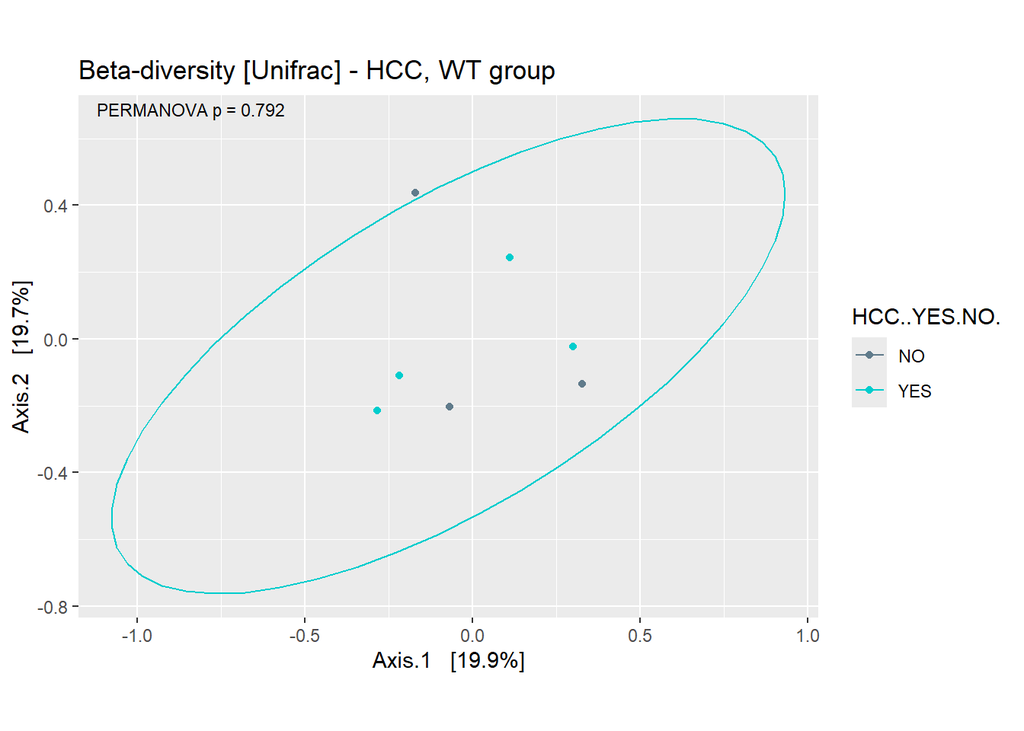

```r
# Calculem matriu de distància Unifrac
physeqWT_unifrac <- ordinate(physeq.WT, method = "PCoA", distance = "unifrac")
evalues_unifrac_WT <- physeqWT_unifrac$values$Eigenvalues

# Gràfic d'ordenades per distància Unifrac
plot_ordination(physeq.WT, physeqWT_unifrac, color = "HCC..YES.NO.") +
  labs(col = "HCC..YES.NO.") +
  coord_fixed(sqrt(evalues_unifrac_WT[2]/ evalues_unifrac_WT[1])) +
  stat_ellipse() +
  annotate("text", label = Pvalue_permanova_unifrac_WT.HCC, x = -Inf, y = Inf,  hjust = -0.1, vjust = 1.5, size = 3) +
  ggtitle("Beta-diversity [Unifrac] - HCC, WT group") +
  scale_color_manual(values = c("YES" = "#00CDCD", "NO" = "#607B8B"))
```

```r
ggsave("beta-div_WT_Unifrac.jpeg", path = "R_analysis", dpi = 600, height = 8, width = 7)
```

```
## Too few points to calculate an ellipse
```

```
## Too few points to calculate an ellipse
```

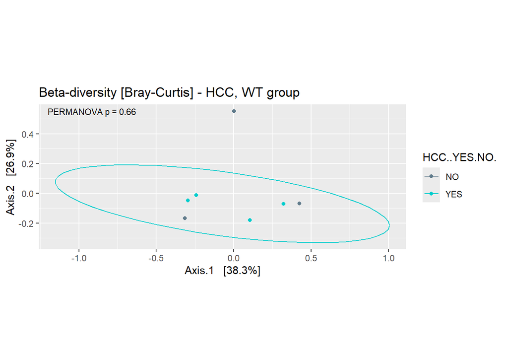

```r
# Càlcul matriu de distància Bray-Curtis
physeqWT_bray <- ordinate(physeq.WT, method = "PCoA", distance = "bray")
evalues_bray_WT <- physeqWT_bray$values$Eigenvalues

# Gràfic d'ordenades per distància Bray-Curtis
plot_ordination(physeq.WT, physeqWT_bray, color = "HCC..YES.NO.") +
  labs(col = "HCC..YES.NO.") +
  coord_fixed(sqrt(evalues_bray[2]/ evalues_bray[1])) +
  stat_ellipse() +
  annotate("text", label = Pvalue_permanova_bray_WT.HCC, x = -Inf, y = Inf,  hjust = -0.1, vjust = 1.5, size = 3) +
  ggtitle("Beta-diversity [Bray-Curtis] - HCC, WT group") +
  scale_color_manual(values = c("YES" = "#00CDCD", "NO" = "#607B8B"))
```

```r
ggsave("beta-div_WT_Bray.jpeg", path = "R_analysis", dpi = 600, height = 8, width = 7)
```

```
## Too few points to calculate an ellipse
```

## Segons aparició de tumors, en grup KO

```r
# Calculem la matriu de distàncies unifrac
physeq.KO.unifrac <- phyloseq::distance(physeq.KO, method= "unifrac")

# Test PERMANOVA - WT/HCC
permanova_unifrac_KO.HCC <- adonis2(physeq.KO.unifrac ~ HCC..YES.NO., data = data.frame(sample_data(physeq.KO)), permutations= 999)
Pvalue_permanova_unifrac_KO.HCC <- paste0("PERMANOVA p = ", signif(permanova_unifrac_KO.HCC$`Pr(>F)`[1]))

# Calculem la matriu de distàncies Bray-Curtis
physeq.KO.bray <- phyloseq::distance(physeq.KO, method= "bray")

# Test PERMANOVA - WT/HCC
permanova_bray_KO.HCC <- adonis2(physeq.KO.bray ~ HCC..YES.NO., data = data.frame(sample_data(physeq.KO)), permutations= 999)
Pvalue_permanova_bray_KO.HCC <- paste0("PERMANOVA p = ", signif(permanova_bray_KO.HCC$`Pr(>F)`[1]))
```

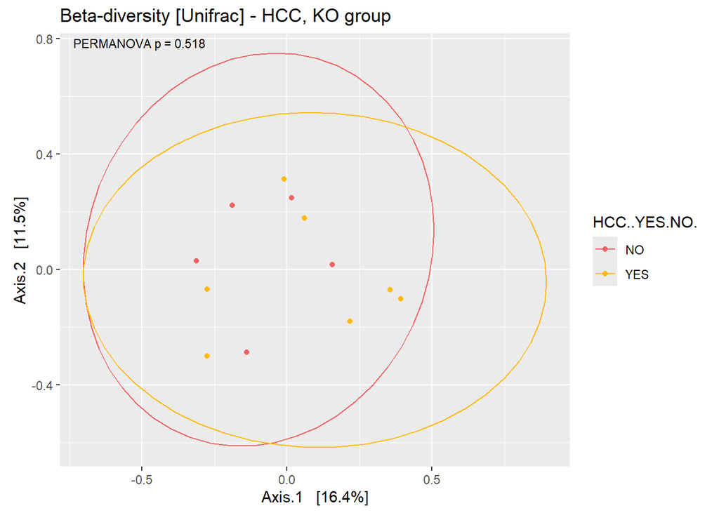

```r
# Calculem matriu de distància Unifrac
physeqKO.mds.unifrac <- ordinate(physeq.KO, method = "MDS", distance = "unifrac")
evalues_unifrac_KO <- physeqKO.mds.unifrac$values$Eigenvalues

# Gràfic d'ordenades per distància Unifrac
plot_ordination(physeq.KO, physeqKO.mds.unifrac, color = "HCC..YES.NO.") +
  labs(col = "HCC..YES.NO.") +
  coord_fixed(sqrt(evalues_unifrac_WT[2]/ evalues_unifrac_WT[1])) +
  stat_ellipse() +
  annotate("text", label = Pvalue_permanova_unifrac_KO.HCC, x = -Inf, y = Inf,  hjust = -0.1, vjust = 1.5, size = 3) +
  ggtitle("Beta-diversity [Unifrac] - HCC, KO group") +
  scale_color_manual(values = c("YES" = "#FFB90F", "NO" = "#EE6363"))
```

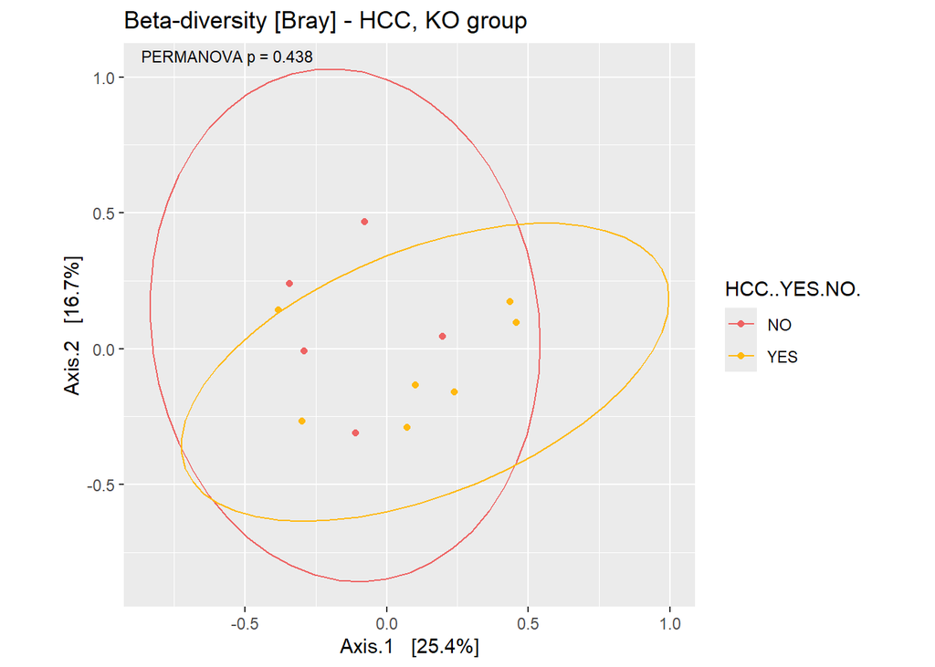

```r
ggsave("beta-div_KO_Unifrac.jpeg", path = "R_analysis", dpi = 600, height = 8, width = 7)

# Càlcul matriu de distància Bray-Curtis
physeqKO.mds.bray <- ordinate(physeq.KO, method = "MDS", distance = "bray")
evalues_bray_KO <- physeqKO.mds.bray$values$Eigenvalues

# Gràfic d'ordenades per distància Bray-Curtis
plot_ordination(physeq.KO, physeqKO.mds.bray, color = "HCC..YES.NO.") +
  labs(col = "HCC..YES.NO.") +
  coord_fixed(sqrt(evalues_bray[2]/ evalues_bray[1])) +
  stat_ellipse() +
  annotate("text", label = Pvalue_permanova_bray_KO.HCC, x = -Inf, y = Inf, size = 3, hjust = -0.1, vjust = 1.5) +
  ggtitle("Beta-diversity [Bray] - HCC, KO group") +
  scale_color_manual(values = c("YES" = "#FFB90F", "NO" = "#EE6363"))
```

```r
ggsave("beta-div_KO_Bray.jpeg", path = "R_analysis", dpi = 600, height = 8, width = 7)
```

# 4. Caracterització composicional

Per tenir una visió general de la composició de les mostres farem servir gràfics de barres apilades.

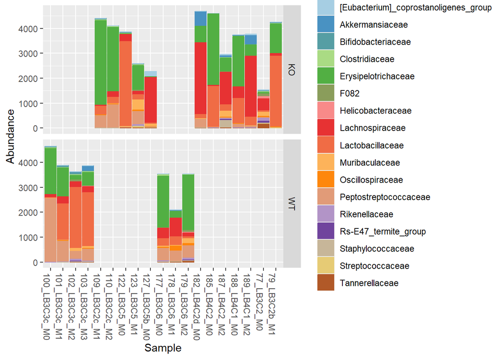

```r
# Obtenim els taxons més abundants (top 50)
top50_OTUs <- names(sort(taxa_sums(physeq3), TRUE)[1:50])

# Els filtrem utilitzant prune_taxa
top50_filter <- prune_taxa(top50_OTUs, physeq3)

# Crear paleta extendida
extended_palette <- colorRampPalette(brewer.pal(12, "Paired"))(17)

# Grafiquem per familia
plot_bar(top50_filter, fill = "Family", facet_grid = "Genotype") +
  geom_bar(aes(color=Family, fill=Family), stat="identity", position="stack") +
  scale_fill_manual(values = extended_palette) +
  scale_color_manual(values = extended_palette)
```

```r
ggsave("barplot_family.jpeg", device = "jpeg", path = "R_analysis", width = 10, dpi = 1500)
```

# 5. Clustering

```r
# Agrupar els OTUs per nivell taxonòmic "Family"
physeq_family <- tax_glom(top50_filter, taxrank = "Family")

# Expressem otu_table com a matrix
otu <- as.matrix(otu_table(physeq_family))

# Extraiem les taxonomies
taxonomy <- tax_table(physeq_family)
family_labels <- taxonomy[, "Family"]

# Extraiem metadata, combinem les dos variables genotype + hcc per fer el clustering
metadata <- sample_data(physeq_family)
metadata$genotype_hcc <- factor(paste(metadata$Genotype, metadata$HCC..YES.NO., sep = "_"))
genotype_hcc <- metadata[, "genotype_hcc"]

# Grafiquem les relacions entre mostres segons cada grup - genotip + HCC

  # Creem anotació pels slices
  slice_anotacio <- HeatmapAnnotation(genotype_hcc = anno_block(
    gp = gpar(fill = c("#FFB90F", "#EE6363", "#00CDCD", "#607B8B")),
    labels = c("KO_YES", "KO_NO", "WT_YES", "WT_NO"),
    labels_gp = gpar(col = "white", fontsize = 5, fontface = "bold")))

png("R_analysis/heatmap_genotypeHCC.png", width = 5000, height = 5000, res = 600)
Heatmap(otu,
        name = "OTU Abundance",
        column_split = genotype_hcc,
        cluster_column_slices = TRUE,
        top_annotation = slice_anotacio,
        cluster_rows = FALSE,
        row_labels = family_labels,
        row_dend_side = "left",
        row_names_gp = gpar(fontsize = 8),
        column_names_rot = -45,
        column_names_gp = gpar(fontsize = 5),
        column_gap = unit(0.5,"mm"),
        col = hcl.colors(10),
        width = unit(5, "cm"),
        height = unit(8, "cm"))
dev.off()
```

```r
# Fem l'estudi de clustering amb la matriu de distàncies Bray-Curtis
  # Calculem la matriu de distàncies - Bray-Curtis per columnes
  matrix.bray <- phyloseq::distance(physeq_family, method= "bray")

  # Calcular el dendrograma basat en la matriu de distàncies
  hc <- hclust(as.dist(matrix.bray))

  # Extreure l'ordre de les mostres basat en el dedograma
  column_order <- hc$order

  # Crear un vector de colors segons la variable genotype_hcc
  color_labels <- c("KO_NO" = "#EE6363", "KO_YES" = "#FFB90F", "WT_NO" = "#607B8B", "WT_YES" = "#00CDCD")

  # Assignar els colors a cada mostra (columna) en funció de la variable genotype_hcc, i ordenar segons la matriu de distàncies
  column_colors <- color_labels[metadata$genotype_hcc]  # El problema és aqui!
  ordered_column_colors <- column_colors[column_order]

png("R_analysis/heatmap_genotypeHCC_distance.png", width = 5000, height = 5000, res = 600)
Heatmap(otu,
        name = "OTU Abundance",
        cluster_rows = FALSE,
        cluster_columns = FALSE,
        row_labels = family_labels,
        row_dend_side = "left",
        row_names_gp = gpar(fontsize = 8),
        column_names_rot = -45,
        column_names_gp = gpar(fontsize = 5, col = column_colors),
        column_gap = unit(0.5,"mm"),
        col = hcl.colors(10),
        width = unit(5, "cm"),
        height = unit(8, "cm"),
        column_order = column_order)
dev.off()
```

# 6. Anàlisi d’abundància diferencial

Per determinar quins taxons estan més representats en una condició, es fa servir el mateix procés que en l’anàlisi d’expressió diferencial de gens (ie RNA-seq). Per això, es fa servir el paquet DESeq2.

## En funció del genotip

Primer generem un objecte DESeq. Amb la funció, es normalitza la mida de les mostres (num de reads), i la variabilitat - per default es realitza amb el test paramètric de correcció Benjamini-Hochberg. A més, calculem les mitjanes geomètriques abans de estimar la mida dels factors.

```r
physeq_ddseq = phyloseq_to_deseq2(physeq3, ~Genotype)
# Normalitzem les mostres
gm_mean = function(x, na.rm=TRUE){
    exp(sum(log(x[x > 0]), na.rm=na.rm) / length(x))
}
geoMeans = apply(counts(physeq_ddseq), 1, gm_mean)
physeq_ddseq = estimateSizeFactors(physeq_ddseq, geoMeans = geoMeans)
physeq_ddseq = DESeq(physeq_ddseq, fitType = "local")
```

```
## -- replacing outliers and refitting for 97 genes
## -- DESeq argument 'minReplicatesForReplace' = 7
## -- original counts are preserved in counts(dds)
```

Ara ja podem revisar els resultats, establint un llindar de significància:

```r
Deseq_res_genotype = results(physeq_ddseq)
Deseq_res_genotype = Deseq_res_genotype[order(Deseq_res_genotype$padj, na.last=NA), ]

# Establim el llindar i filtrem l'objecte Deseq, i finalment afegim els taxons
alpha = 0.05
Deseq_res_genotype_filtered <- Deseq_res_genotype[(Deseq_res_genotype$padj < alpha), ]
Deseq_res_genotype_filtered <- cbind(as(Deseq_res_genotype_filtered, "data.frame"), as(tax_table(physeq3)[rownames(Deseq_res_genotype_filtered), ], "matrix"))
kable(Deseq_res_genotype_filtered)
```

|  | baseMean | log2FoldChange | lfcSE | stat | pvalue | padj | Kingdom | Phylum | Class | Order | Family | Genus | Species |
| --- | --- | --- | --- | --- | --- | --- | --- | --- | --- | --- | --- | --- | --- |
| 21c00fdc9e25f01a0298fdab6f02f8e03c7f20b4 | 9.631579 | -21.700595 | 3.090433 | -7.021862 | 0e+00 | 0.0000000 | d__Bacteria | Firmicutes | Bacilli | Erysipelotrichales | Erysipelotrichaceae | Allobaculum | NA |
| 004165eacc69feb0585002c7b93882e99f3073aa | 11.421053 | 7.396872 | 1.505300 | 4.913884 | 9e-07 | 0.0074414 | d__Bacteria | Firmicutes | Clostridia | Lachnospirales | Lachnospiraceae | uncultured | NA |

Aquí ja hem pogut veure que hi ha 2 OTUs significativament diferents. El primer está sobrerepresentat en el grup KO, y el segon en el grup WT.

També ho podem representar, farem filum i family perque a nivell de gènere no tenim molta informació:

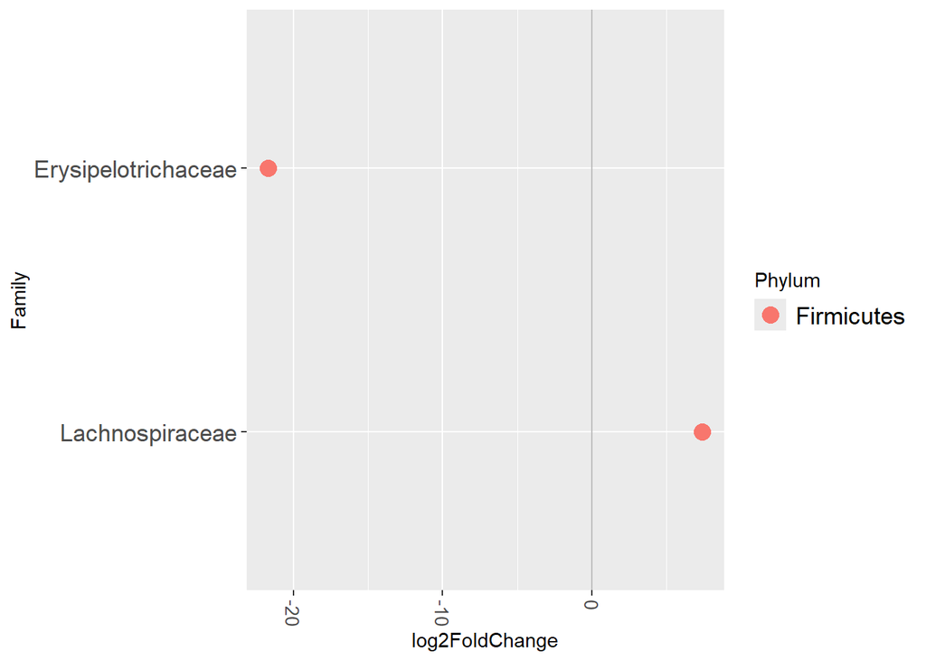

```r
# Phylum order
x = tapply(Deseq_res_genotype_filtered$log2FoldChange, Deseq_res_genotype_filtered$Phylum, function(x) max(x))
x = sort(x, TRUE)
Deseq_res_genotype_filtered$Phylum = factor(as.character(Deseq_res_genotype_filtered$Phylum), levels=names(x))

# Family order
x = tapply(Deseq_res_genotype_filtered$log2FoldChange, Deseq_res_genotype_filtered$Family, function(x) max(x))
x = sort(x, TRUE)
Deseq_res_genotype_filtered$Family = factor(as.character(Deseq_res_genotype_filtered$Family), levels=names(x))

ggplot(Deseq_res_genotype_filtered, aes(y=Family, x=log2FoldChange, color=Phylum)) +
    geom_vline(xintercept = 0.0, color = "gray", size = 0.5) +
    geom_point(size=4) +
    theme(axis.text.x = element_text(angle = -90, hjust = 0, vjust=0.5, size = 10), axis.text.y = element_text(size = 13), legend.text = element_text(size = 13) )
```

```r
ggsave("DeSeq.jpeg", path = "R_analysis", width = 10, dpi = 1500)
```

## Segons l’aparició de tumors, independentment del genotip

```r
physeq_ddseq_HCC = phyloseq_to_deseq2(physeq3, ~HCC..YES.NO.)
# Normalitzem les mostres
geoMeans = apply(counts(physeq_ddseq_HCC), 1, gm_mean)
physeq_ddseq_HCC = estimateSizeFactors(physeq_ddseq_HCC, geoMeans = geoMeans)
physeq_ddseq_HCC = DESeq(physeq_ddseq_HCC, fitType = "local")
```

```
## -- replacing outliers and refitting for 107 genes
## -- DESeq argument 'minReplicatesForReplace' = 7
## -- original counts are preserved in counts(dds)
```

Ara ja podem revisar els resultats, establint un llindar de significància:

```r
Deseq_res_HCC = results(physeq_ddseq_HCC)
Deseq_res_HCC = Deseq_res_HCC[order(Deseq_res_HCC$padj, na.last=NA), ]
Deseq_res_HCC <- cbind(as(Deseq_res_HCC, "data.frame"), as(tax_table(physeq3)[rownames(Deseq_res_HCC), ], "matrix"))
head(Deseq_res_HCC)
```

|  | baseMean | log2FoldChange | lfcSE | stat | pvalue | padj | Kingdom | Phylum | Class | Order | Family | Genus | Species |
| --- | --- | --- | --- | --- | --- | --- | --- | --- | --- | --- | --- | --- | --- |
| 962ed07ffd603220a6a0291cc8e7567249adb770 | 0.05263158 | 0.2622924 | 3.071950 | 0.08538301 | 0.9319569 | 0.983243 | d__Bacteria | NA | NA | NA | NA | NA | NA |
| 2dde6d6855c2756c9c2133864d2f73fca4371c8b | 0.05263158 | 0.2622924 | 3.071950 | 0.08538301 | 0.9319569 | 0.983243 | d__Bacteria | NA | NA | NA | NA | NA | NA |
| ae5c6f6d617a989d65be21b4aa37f0eb2a5de250 | 0.05263158 | 0.2622924 | 3.071950 | 0.08538301 | 0.9319569 | 0.983243 | d__Bacteria | NA | NA | NA | NA | NA | NA |
| 75462f38656f5de3b83609cd8f681d6c10a9ff54 | 0.15789474 | -1.0820187 | 2.969004 | -0.36443825 | 0.7155308 | 0.983243 | d__Bacteria | NA | NA | NA | NA | NA | NA |
| 5ec8b0054b472d852453a56ab5ec933f716957db | 0.05263158 | 0.2622924 | 3.071950 | 0.08538301 | 0.9319569 | 0.983243 | d__Bacteria | NA | NA | NA | NA | NA | NA |
| a6ef626060c8835665ac665502a786d25df47104 | 0.05263158 | -0.3606817 | 3.071950 | -0.11741132 | 0.9065341 | 0.983243 | d__Bacteria | NA | NA | NA | NA | NA | NA |

Després d’ordenar les mostres veiem que no hi ha diferències significatives en cap OTU, pel que l’anàlisis acabaria aquí.

## Segons l’aparició de tumors, només en WT

```r
physeq_ddseq_WT = phyloseq_to_deseq2(physeq.WT, ~HCC..YES.NO.)
# Normalitzem les mostres
geoMeans = apply(counts(physeq_ddseq_WT), 1, gm_mean)
physeq_ddseq_WT = estimateSizeFactors(physeq_ddseq_WT, geoMeans = geoMeans)
physeq_ddseq_WT = DESeq(physeq_ddseq_WT, fitType = "local")
```

Ara ja podem revisar els resultats, establint un llindar de significància:

```r
Deseq_res_WT = results(physeq_ddseq_WT)
Deseq_res_WT = Deseq_res_WT[order(Deseq_res_WT$padj, na.last=NA), ]
Deseq_res_WT <- cbind(as(Deseq_res_WT, "data.frame"), as(tax_table(physeq.WT)[rownames(Deseq_res_WT), ], "matrix"))
kable(head(Deseq_res_WT))
```

|  | baseMean | log2FoldChange | lfcSE | stat | pvalue | padj | Kingdom | Phylum | Class | Order | Family | Genus | Species |
| --- | --- | --- | --- | --- | --- | --- | --- | --- | --- | --- | --- | --- | --- |
| 75462f38656f5de3b83609cd8f681d6c10a9ff54 | 0.2857143 | -1.8577108 | 3.771228 | -0.4926010 | 0.6222946 | 0.9338405 | d__Bacteria | NA | NA | NA | NA | NA | NA |
| e574a8f42269faa6166202bfa43891c1fb9142c1 | 0.1428571 | 0.7213167 | 3.816939 | 0.1889778 | 0.8501102 | 0.9338405 | d__Bacteria | NA | NA | NA | NA | NA | NA |
| 1e33b13f6039fef3648086296fbfebcb4033c985 | 0.4285714 | 2.0276084 | 3.771227 | 0.5376522 | 0.5908172 | 0.9338405 | d__Bacteria | NA | NA | NA | NA | NA | NA |
| d3cee13efbd5ecdbe2962d45c844d6c331e5ce3e | 0.1428571 | -0.9617950 | 3.816939 | -0.2519807 | 0.8010559 | 0.9338405 | d__Bacteria | NA | NA | NA | NA | NA | NA |
| 432625afbb6bbfcb7c9ab55550beb3bb9b8dcd30 | 0.1428571 | -0.9617950 | 3.816939 | -0.2519807 | 0.8010559 | 0.9338405 | d__Bacteria | NA | NA | NA | NA | NA | NA |
| a3f945a4f62aeb890a0bec36e64912c3057b288c | 0.1428571 | -0.9617950 | 3.816939 | -0.2519807 | 0.8010559 | 0.9338405 | d__Bacteria | NA | NA | NA | NA | NA | NA |

Mirant només diferències en WT tampoc trobem diferències entre els que desenvolupen i no tumors.

## Segons l’aparició de tumors, només en KO

```r
physeq_ddseq_KO = phyloseq_to_deseq2(physeq.KO, ~HCC..YES.NO.)
# Normalitzem les mostres
geoMeans = apply(counts(physeq_ddseq_KO), 1, gm_mean)
physeq_ddseq_KO = estimateSizeFactors(physeq_ddseq_KO, geoMeans = geoMeans)
physeq_ddseq_KO = DESeq(physeq_ddseq_KO, fitType = "local")
```

```
## -- replacing outliers and refitting for 63 genes
## -- DESeq argument 'minReplicatesForReplace' = 7
## -- original counts are preserved in counts(dds)
```

Ara ja podem revisar els resultats, establint un llindar de significància:

```r
Deseq_res_KO = results(physeq_ddseq_KO)
Deseq_res_KO = Deseq_res_KO[order(Deseq_res_KO$padj, na.last=NA), ]
Deseq_res_KO <- cbind(as(Deseq_res_KO, "data.frame"), as(tax_table(physeq.KO)[rownames(Deseq_res_KO), ], "matrix"))
kable(head(Deseq_res_KO))
```

|  | baseMean | log2FoldChange | lfcSE | stat | pvalue | padj | Kingdom | Phylum | Class | Order | Family | Genus | Species |
| --- | --- | --- | --- | --- | --- | --- | --- | --- | --- | --- | --- | --- | --- |
| 962ed07ffd603220a6a0291cc8e7567249adb770 | 0.0833333 | 0.4121802 | 3.160744 | 0.1304061 | 0.8962452 | 0.9599207 | d__Bacteria | NA | NA | NA | NA | NA | NA |
| 2dde6d6855c2756c9c2133864d2f73fca4371c8b | 0.0833333 | 0.4121802 | 3.160744 | 0.1304061 | 0.8962452 | 0.9599207 | d__Bacteria | NA | NA | NA | NA | NA | NA |
| ae5c6f6d617a989d65be21b4aa37f0eb2a5de250 | 0.0833333 | 0.4121802 | 3.160744 | 0.1304061 | 0.8962452 | 0.9599207 | d__Bacteria | NA | NA | NA | NA | NA | NA |
| 75462f38656f5de3b83609cd8f681d6c10a9ff54 | 0.0833333 | -0.5770831 | 3.160744 | -0.1825782 | 0.8551290 | 0.9599207 | d__Bacteria | NA | NA | NA | NA | NA | NA |
| 5ec8b0054b472d852453a56ab5ec933f716957db | 0.0833333 | 0.4121802 | 3.160744 | 0.1304061 | 0.8962452 | 0.9599207 | d__Bacteria | NA | NA | NA | NA | NA | NA |
| a6ef626060c8835665ac665502a786d25df47104 | 0.0833333 | -0.5770831 | 3.160744 | -0.1825782 | 0.8551290 | 0.9599207 | d__Bacteria | NA | NA | NA | NA | NA | NA |

Igual, tampoc hi ha diferències.

## Finalment ho mirarem segons la gàbia/camàdes

```r
physeq_ddseq_B = phyloseq_to_deseq2(physeq3, ~Brood)
# Normalitzem les mostres
geoMeans = apply(counts(physeq_ddseq_B), 1, gm_mean)
physeq_ddseq_B = estimateSizeFactors(physeq_ddseq_B, geoMeans = geoMeans)
physeq_ddseq_B = DESeq(physeq_ddseq_B, fitType = "local")
```

Ara ja podem revisar els resultats, establint un llindar de significància:

```r
Deseq_res_B = results(physeq_ddseq_B)
Deseq_res_B = Deseq_res_B[order(Deseq_res_B$padj, na.last=NA), ]
Deseq_res_B <- cbind(as(Deseq_res_B, "data.frame"), as(tax_table(physeq3)[rownames(Deseq_res_B), ], "matrix"))
head(Deseq_res_B)
```

|  | baseMean | log2FoldChange | lfcSE | stat | pvalue | padj | Kingdom | Phylum | Class | Order | Family | Genus | Species |
| --- | --- | --- | --- | --- | --- | --- | --- | --- | --- | --- | --- | --- | --- |
| 962ed07ffd603220a6a0291cc8e7567249adb770 | 0.05263158 | 2.4423799368 | 9.235115 | 2.644666e-01 | 0.7914204 | 0.9999894 | d__Bacteria | NA | NA | NA | NA | NA | NA |
| 2dde6d6855c2756c9c2133864d2f73fca4371c8b | 0.05263158 | -0.0001697425 | 9.347078 | -1.815996e-05 | 0.9999855 | 0.9999894 | d__Bacteria | NA | NA | NA | NA | NA | NA |
| ae5c6f6d617a989d65be21b4aa37f0eb2a5de250 | 0.05263158 | -0.0001697425 | 9.347078 | -1.815996e-05 | 0.9999855 | 0.9999894 | d__Bacteria | NA | NA | NA | NA | NA | NA |
| 75462f38656f5de3b83609cd8f681d6c10a9ff54 | 0.15789474 | -0.0002327699 | 9.347078 | -2.490297e-05 | 0.9999801 | 0.9999894 | d__Bacteria | NA | NA | NA | NA | NA | NA |
| 5ec8b0054b472d852453a56ab5ec933f716957db | 0.05263158 | -0.0002134272 | 9.347078 | -2.283358e-05 | 0.9999818 | 0.9999894 | d__Bacteria | NA | NA | NA | NA | NA | NA |
| a6ef626060c8835665ac665502a786d25df47104 | 0.05263158 | -0.0001697425 | 9.347078 | -1.815996e-05 | 0.9999855 | 0.9999894 | d__Bacteria | NA | NA | NA | NA | NA | NA |

Tampoc hi ha diferències.